# Using Machine Learning Fundamentals to Exit the Andromeda Galaxy

Charlotte Xu

January 12th, 2025

## Introduction

Every day machine learning tools are helping us solve bigger and more difficult problems. For example, you probably know about how ChatGPT can help you write essays and emails, or how DALL-E can generate an image of whatever you want. But you have probably also heard that computers are just very big calculators that add, multiply and store binary numbers. So how on earth have we turned giant calculators into devices that can write emails? The trick is that we discovered how to do machine learning; the art of programming computers so that they can *learn* how to perform difficult tasks. Today, I’m going to show you the basics of how this works, and even create a basic machine learning models to predict meteor showers! But first, let’s close our eyes and imagine for a bit…

## The Fundamentals of Machine Learning

…imagine that you are alone and stuck on another planet 🪐 (like in The Martian!). Your specialty is engineering so you have managed to assemble a rocketship, but this planet has frequent meteor showers️ that can destroy your rocketship if you take off at the wrong time. So you really need to know when it will be safe to launch your rocket and head back to earth, but you don’t understand what causes the meteor showers and all you have is a computer to help you. Having a computer sounds like it could be really helpful, but remember that a computer has no inherent knowledge or ability to understand your problem. All computers actually do is execute whatever instructions they are given. Of course, on earth we can use the internet to get knowledge and helpful programs, but on this far away planet you don’t have access to that. So even though we know nothing about the meteor showers, how do we get the computer to tell us when we should launch our rocket? 🚀🚀🚀

[figure not shown]

It turns out that all machine learning starts from formulating the problem into a prediction task:

- Google Translate predicts what the translated sentence will be given your input sentence.
- ChatGPT predicts the next word in a response given what your prompt is.
- DALL-E predicts the next step in denoising an image given what your prompt is

If we would like to know when it will be safe to launch the rocket, we can reformulate this into a prediction problem by thinking about predicting when meteor showers will occur, and then we can launch our rocket when the predicted probability of meteor showers is low.

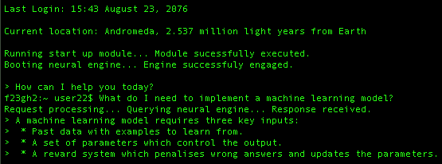

Our Computer Terminal in the Andromeda Galaxy

But to predict, our computer will need three things:

- Past data with examples to learn from.
- A model architecture and parameters which control the output.
- A reward system which penalises wrong answers and updates the parameters.

Let’s go through each of these so we can understand them, and then we’ll get to the fun part of building a model!

### Data

So let’s say you go out and collect one year of meteor shower data. That means you go outside from time to time and record all the artefacts you see in the sky, and then record if a meteor shower occurred within the next hour. Your final dataset might look something like this:

| time | sporatic_meteors | ion_in_atmosphere | dust_ion_tails | meteor_shower |
| --- | --- | --- | --- | --- |
| 2076-08-07 00:00:00 | 0 | 1 | 0 | 0 |
| 2076-08-07 01:00:00 | 1 | 0 | 1 | 0 |
| 2076-08-07 02:00:00 | 0 | 1 | 0 | 0 |
| 2076-08-07 03:00:00 | 1 | 0 | 1 | 1 |
| 2076-08-07 04:00:00 | 1 | 1 | 1 | 1 |
| 2076-08-07 05:00:00 | 0 | 1 | 0 | 0 |

- $meteor\_shower$ records whether a meteor shower occurred in that hour our or not. We set $meteor\_shower = 1$ if a meteor shower occurred and $meteor\_shower = 0$ if it didn’t. This is the variable that we want to learn to predict.
- $sporatic\_meteors$ records whether we saw a few meteors in the sky at the beginning of the hour - usually one or two meteors will occur before a large meteor shower. Again, if we saw sporadic meteors then we set $sporatic\_meteors = 1$ and otherwise we set $sporatic\_meteors = 0$. $sporatic\_meteors$ is a variable that we will use to help us predict $meteor\_shower$.
- $ion\_in\_atmosphere$ records whether we detected increased ionisation in the upper atmosphere with our radio equipment. Increased ionisation means that a meteor shower may be about to intensify. We set $ion\_in\_atmosphere = 1$ if we detected increased ionisation and $ion\_in\_atmosphere = 0$ if we didn’t.
- $dust\_ion\_tails$ records whether we can see dust and ion trails in the atmosphere - which usually occurs before a big meteor shower. We set $dust\_ion\_tails = 1$ if saw dust and ion trails in the atmosphere and $dust\_ion\_tails = 0$ if we didn’t.

So now that we have our data, the next step is to choose a model that can learn from the data to predict when meteor showers will occur…

### Model Architecture

There’s a lot of advanced model architectures that we could choose, but today we will begin with one of the simplest high performing models: linear regression. Although linear regression doesn’t power the cutting edge machine learning tools I mentioned earlier, it’s still the number one machine learning model in use today, including at places like [NASA](https://ntrs.nasa.gov/api/citations/20230008115/downloads/CCAAW23_CSU_Link_Selection%20Final.pdf), [TwoSigma](https://www.twosigma.com/articles/sparse-pca-from-sparse-linear-regression/) and many more.

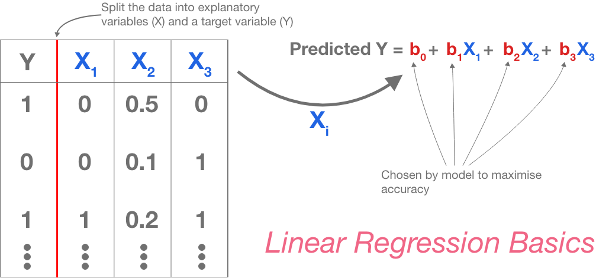

The Basic Architecture of Linear Regression

The linear regression model concept is very simple:

- We separate the data into a “target variable” that we want to predict and “explanatory variables” which we think might be able to predict our target variable.
- Each explanatory variable is multiplied by a parameter (i.e. a number), and then we add it all together.
- If our model performs poorly, we update the parameters to make sure it does better later (more on this soon).

To pick a super simple example, if we wanted to predict when are likely to buy food, we might have a dataset and model like this:

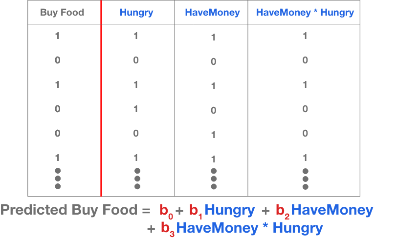

You can probably see in this basic case that the best performing parameters will be:

$$b_0 = 0, \; b_1 = 0, \; b_2 = 0, \;
\text{and} \; b_3 = 1$$

because when we are hungry and have money, that’s when we buy food!

### Reward System

That brings us to the final step; we need to decide on a reward system. There’s actually two components to this:

- An objective function. This tells the model how good its predictions actually are. Usually good answers get a small value and bad answers get a high value, so the model tries to minimise the output of the objective function.
- Parameter update mechanism. When the machine learning model receives feedback from the objective function, the parameter update mechanism says how the parameters should change to make the result better next time.

You might have noticed that the objective function is inspired by nature. If you think about humans and other animals, we all have a fundamental objective function - pain. When we make a mistake (e.g. touch a hot stove 🔥), you receive feedback from your “objective function” in the form of pain, and you learn not to do that painful thing again! You try to minimise pain, and that turns out to be a good strategy for getting through life safely!

For our case we will pick the sum of squared errors objective function and the minimisation parameter update mechanism, which are very common choices in all machine learning models.

The sum of squared errors is very simple:

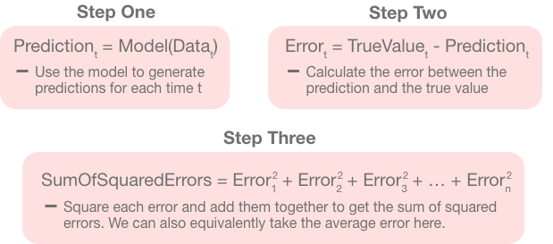

so essentially: if the model gets really close to the true value, the magnitude of each error will be small, and therefore the square and sum of these errors will be small as well.

We’ll cover the minimisation update mechanism in detail soon, but it’s actually highly related to what we know from calculus - if we set the derivative of the objective function to 0, we can solve for the optimal parameters 🤯

## Implementing Our Model

That was a lot of explaining! But don’t worry if it hasn’t all clicked yet, because now we get to the fun part 😄

We have 8784 rows of data, that’s more than enough to build a model, so let’s get cracking!

```r
nrow(meteor_data)
```

```
## [1] 8784
```

### Finalising the Model Architecture

First, we need think about our model. When we are predicting Y, we are really trying to create a model that closely fits the true relationship of Y and X. So we want a model that can replicate complex relationships between Y and X.

Our model is called **linear** regression, so you might think that we can only model linear relationships - like for example this function of $Y = 1 + 0.5X$

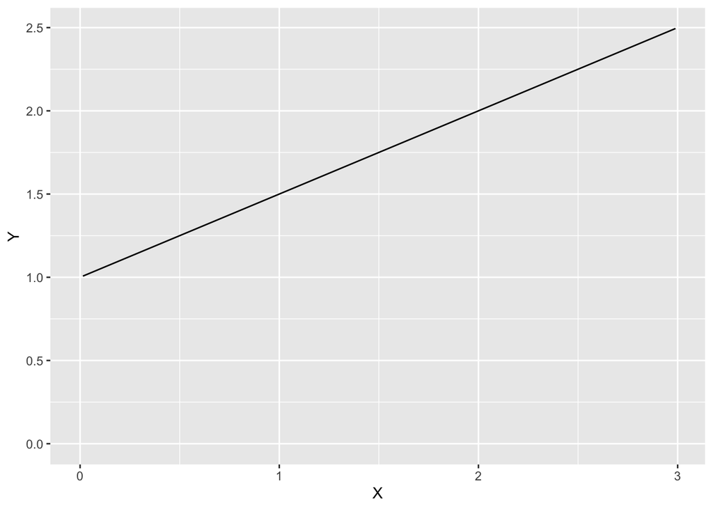

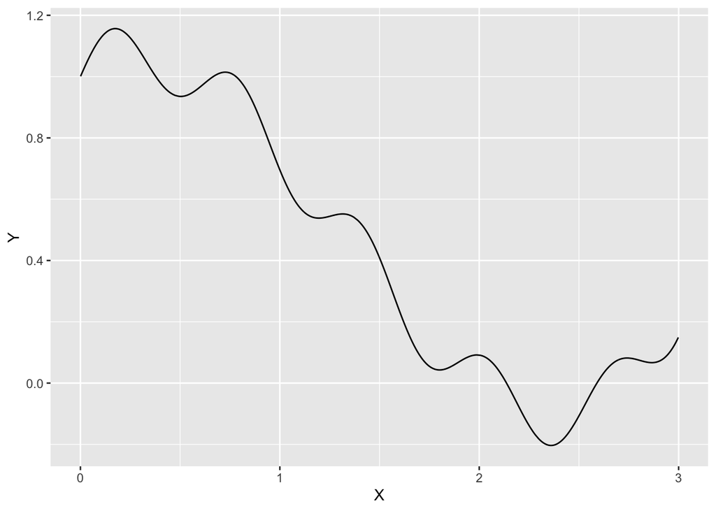

Now imagine what would occur if we add other variables like $Z$ and interaction terms like $Z \times X^2$ or $Z^5 \times \sqrt{X}$ - that gets really complex quite quickly! It actually turns out that [any function can be approximated with linear regression](https://en.wikipedia.org/wiki/Stone%E2%80%93Weierstrass_theorem), so we shouldn’t worry about our model being too “simple”.

We have predictors for increased atmospheric ionisation, dust and ion tails in the atmosphere and sporadic meteors so we could create the following prediction model:

$$PredictedMeteorShower_t = \beta_0 +
\beta_1 SporaticMeteor_t + \beta_2 DustIonTails_t + \beta_3
IonInAtmosphere_t$$

So in other words, the prediction for meteor showers at time $t$ depends on if we observed sporatic meteors at time $t$, dust and ion tails at time $t$ or detected increased ion in the atmosphere at time $t$. The parameters $\beta_0$, $\beta_1$, $\beta_2$ and $\beta_3$ are numbers that the model will choose to optimise prediction after training on the data.

But what if $SporaticMeteor$ AND $DustIonTails$ are an important feature? That’s a good point, so we should add all possible interactions as well:

$$\begin{aligned}PredictedMeteorShower_t
&= \beta_0 + \beta_1 SporaticMeteor_t + \beta_2 DustIonTails_t +
\beta_3 IonInAtmosphere_t \\
&+ \beta_4 SporaticMeteor_t * DustIonTails_t +
\beta_5 SporaticMeteor_t * IonInAtmosphere_t \\
&+ \beta_6 DustIonTails_t * IonInAtmosphere_t + \beta_7
SporaticMeteor_t * DustIonTails_t * IonInAtmosphere_T
\end{aligned}$$

Notice that since all our variables are binary (i.e. either 1 or 0), we don’t need to think about including $SporaticMeteor^2$ since $SporaticMeteor^2 = SporaticMeteor$ because $1^2 = 1$ and $0^2 = 0$. It actually turns out that the model above will be able to fit *any* function of $SporaticMeteor$, $DustIonTails$ and $IonInAtmosphere$ - awesome! 😎

First we need to convert our explanatory variables into a matrix - and make sure we include all the interactions. This is really easy to do in R - and don’t worry if you don’t know anything about R - we won’t be doing anything advanced! 🤗

```r
#this funcction will create all the possible interactions of
#sporatic_meteors, dust_ion_tails and ion_in_atmosphere
X <- model.matrix(~ sporatic_meteors * dust_ion_tails * ion_in_atmosphere,
                  data=meteor_data)
```

The first few rows of our $X$ matrix now look like this:

| (Intercept) | sporatic_meteors | dust_ion_tails | ion_in_atmosphere | sporatic_meteors:dust_ion_tails | sporatic_meteors:ion_in_atmosphere | dust_ion_tails:ion_in_atmosphere | sporatic_meteors:dust_ion_tails:ion_in_atmosphere |
| --- | --- | --- | --- | --- | --- | --- | --- |
| 1 | 0 | 0 | 1 | 0 | 0 | 0 | 0 |
| 1 | 1 | 1 | 0 | 1 | 0 | 0 | 0 |
| 1 | 0 | 0 | 1 | 0 | 0 | 0 | 0 |
| 1 | 1 | 1 | 0 | 1 | 0 | 0 | 0 |
| 1 | 1 | 1 | 1 | 1 | 1 | 1 | 1 |
| 1 | 0 | 0 | 1 | 0 | 0 | 0 | 0 |

So each column in this matrix is one of the variables or interaction varibles that we created, and each row represents an observation that we collected for a specific hour. Notice that the intercept “variable” is always $1$ so that $\beta_0 * (Intercept) = \beta_0 * 1 = \beta_0$ - so it’s just a trick 🪄 where we use a fake variable to generate a constant.

### Finding the Error Minimising Parameters

Now let’s think about our model mathematically. What if we define a vector:

$$\vec{\beta} = \begin{bmatrix} \beta_0 \\
\beta_1 \\ \beta_2 \\ \beta_3 \\ \beta_4 \\ \beta_5 \\ \beta_6 \\
\beta_7 \end{bmatrix}$$

Then we can write our predictions as:

This might be a bit tricky to understand - but if you think back to matrix-vector multiplication you’ll see it’s correct. I recommend writing out a few lines of the $X$ matrix and multiplying it by $\vec{\beta}$.

The next trick is to realise that we can write the sum of squared errors with vector multiplication! Let the variable we want to predict be:

So error vector is:

Which means the sum of squared errors is:

If we expand this we have:

$$SumSquaredErrors = \vec{Y}^T \vec{Y} -
\vec{Y}^T X \vec{\beta} - \vec{\beta}^T X^T\vec{Y} + \vec{\beta}^T X^T X
\vec{\beta}$$

But notice that $\vec{Y}^T X \vec{\beta}$ is a scalar, and actually $\vec{Y}^T X \vec{\beta} = \vec{\beta}^T X^T\vec{Y}$. So we can write:

$$SumSquaredErrors = \vec{Y}^T \vec{Y} -
2\vec{\beta}^T X^T \vec{Y} + \vec{\beta}^T X^T X \vec{\beta}$$

Now let’s take stock for a second. Our goal is to solve for the $\vec{\beta}$ which achieves the minimum $SumSquaredErrors$ - this is our parameter update mechanism. But that’s just calculus! In this case, we have matrix calculus, but [the rules are similar](https://www.gatsby.ucl.ac.uk/teaching/courses/sntn/sntn-2017/resources/Matrix_derivatives_cribsheet.pdf):

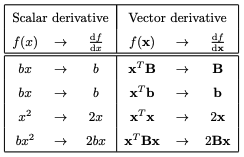

So just following the rules:

$$\frac{\partial
SumSquaredErrors}{\partial \vec{\beta}} = -2 X^T \vec{Y} + 2 X^T X
\vec{\beta}$$

And as always with calculus, we set this derivative equal to 0 to find the minimum and solve 😄

$$-2 X^T \vec{Y} + 2 X^T X \vec{\beta} =
0$$
$$X^T X \vec{\beta} = X^T
\vec{Y}$$
$$(X^T X)^{-1} X^T X
\vec{\beta} = (X^T X)^{-1} X^T \vec{Y}$$
$$\implies \vec{\beta} = (X^T X)^{-1} X^T
\vec{Y}$$

Great! Let’s use the formula on our actual data:

```r
Y <- meteor_data$meteor_shower
beta <- solve(t(X) %*% X) %*% t(X) %*% Y
print(beta)
```

```
##                                                           [,1]
## (Intercept)                                       7.141640e-16
## sporatic_meteors                                  1.819853e-01
## dust_ion_tails                                    1.544771e-15
## ion_in_atmosphere                                 1.814882e-01
## sporatic_meteors:dust_ion_tails                   2.187478e-02
## sporatic_meteors:ion_in_atmosphere                4.178966e-02
## dust_ion_tails:ion_in_atmosphere                  1.777379e-02
## sporatic_meteors:dust_ion_tails:ion_in_atmosphere 5.550883e-01
```

where in R notation “%*%” means matrix multiplication, $t(X) = X^T$ and $\text{solve}(B) = B^{-1}$.

Let’s test out this model and see how well we did 🥳🎉

```r
pred_Y <- X %*% beta
print(head(as.vector(pred_Y)))
```

```
## [1] 0.1814882 0.2038601 0.1814882 0.2038601 1.0000000 0.1814882
```

Our predicted Y’s are actually numbers between 0 and 1 - that makes sense because the model is returning the probability of a meteor shower. If the probability is over 50%, let’s set that to 1 and 0 otherwise.

```r
data.frame(predicted_probability = round(pred_Y, 3),
           predicted_Y = as.numeric(pred_Y > 0.5),
           true_Y = Y) %>%
  head(30)
```

```
##    predicted_probability predicted_Y true_Y
## 1                  0.181           0      0
## 2                  0.204           0      0
## 3                  0.181           0      0
## 4                  0.204           0      1
## 5                  1.000           1      1
## 6                  0.181           0      0
## 7                  0.204           0      0
## 8                  0.405           0      1
## 9                  0.405           0      1
## 10                 0.000           0      0
## 11                 0.204           0      0
## 12                 0.000           0      0
## 13                 0.204           0      0
## 14                 0.405           0      1
```

[output cut: 16 more lines]

There’s a few mistakes there, but overall we clearly did really well! 🥳🎉 In fact, our classification accuracy (i.e. what percentage of the time are the model predictions correct) is nearly 90%!

```r
#classification accuracy
mean(as.numeric(pred_Y > 0.5) == Y)
```

```
## [1] 0.8775046
```

So now our astronaut 🧑‍🚀 can use the model to make a confident prediction of when meteor showers are low enough for take off 🚀

[figure not shown]

Safe travels!